# HiFi Full-length 16S Analysis Report

## Summary QC statistics

- Samples number: 5
- Final samples number post-DADA2: 5
- Missing samples (Not enough reads, do not pass QC, etc):
- Total number of CCS reads before filtering and primers trimming: 216501
- Was primers trimmed prior to DADA2? Yes
- Note that if downsampling was enabled, the reads will be filtered first, then restricted to a maximum of N reads.
- Total number of reads after quality filtering: 211673 (97.77%)
- Total number of reads after primers trimming (DADA2 input): 210139 (99.28%)
- Total number of ASVs found: 765
- Average number of ASVs per sample: 163
- Total number of reads in 765 ASVs: 187948 (89.44% of all input reads)

### Classification using VSEARCH with a single database

- ASVs classified at Species level: 228 (29.8%)
- ASVs classified at Species level (Excluding metagenome/uncultured entries): 228 (29.8%)
- Percentage reads belong to ASV classified at Species level (Excluding metagenome/uncultured entries): 77%
- ASVs classified at Genus level: 233 (30.46%)
- ASVs classified at Genus level (Excluding metagenome/uncultured entries): 233 (30.46%)
- Percentage reads belong to ASV classified at Genus level (Excluding metagenome/uncultured entries): 77%

## Overall reads filtering and number of full-length reads

- Full-length reads are defined as reads with both F27 and R1492 primers
- Note that full length counts column will only show if cutadapt was used to trim primers (default).

|  | Sample | Reads before quality filter | Reads after quality filter | Full-length Reads | Full-length Reads Percent |
| --- | --- | --- | --- | --- | --- |
| 1 | 5A | 34956 | 34243 | 32834 | 0.958852904243203 |
| 2 | 5B | 38431 | 37628 | 37585 | 0.9988572339747 |
| 3 | 5C | 1836 | 1478 | 1422 | 0.962110960757781 |
| 4 | 5D | 82737 | 80999 | 80993 | 0.99992592501142 |
| 5 | 5E_control | 58541 | 57325 | 57305 | 0.999651112080244 |

## Input reads QC (Before filtering and primers removal)

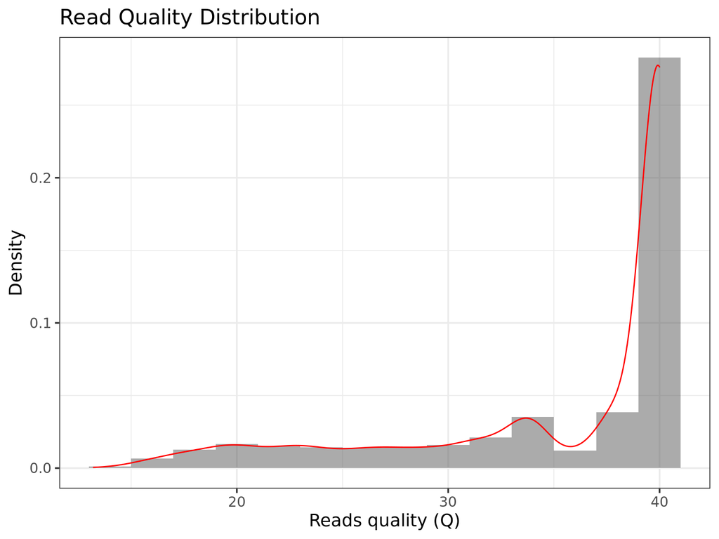

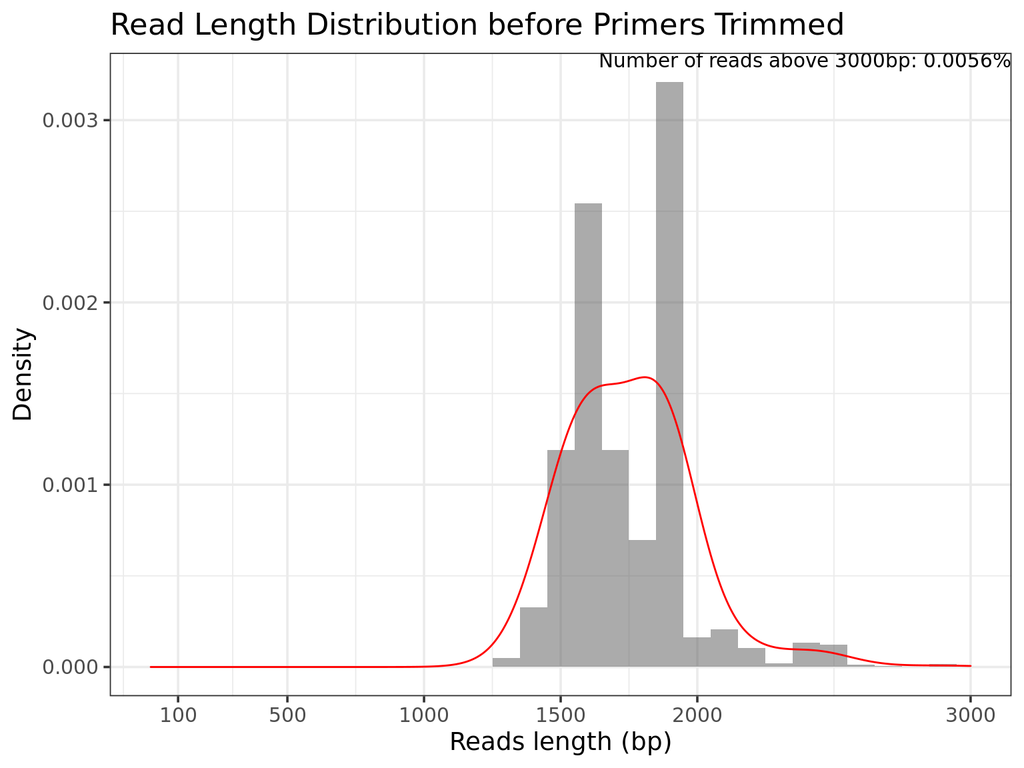

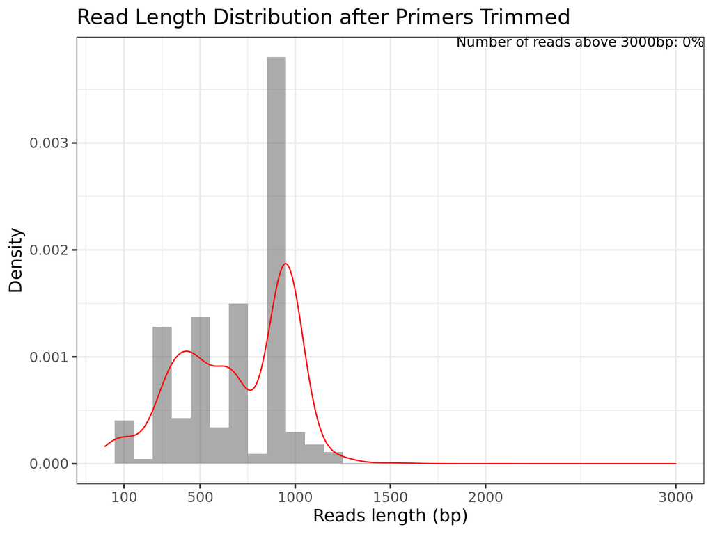

|  | Sample | Median Length (bp) | Median Read Quality | Length 1st Quartile (bp) | Length 3rd Quartile (bp) | Read Quality 1st Quartile (bp) | Read Quality 3rd Quartile (bp) |
| --- | --- | --- | --- | --- | --- | --- | --- |
| 1 | 5A | 1605 | 39.99 | 1483 | 1908 | 37.06 | 40 |
| 2 | 5B | 1884 | 39.98 | 1785 | 1885 | 35.41 | 40 |
| 3 | 5C | 1606 | 28.55 | 1485 | 1848.5 | 21.36 | 39.99 |
| 4 | 5D | 1884 | 39.96 | 1843 | 1884 | 34.47 | 40 |
| 5 | 5E_control | 1661 | 39.51 | 1581 | 1725 | 33.49 | 40 |

## DADA2 QC metrics

|  | sample-id | input | filtered | percentage of input passed filter | denoised | non-chimeric | percentage of input non-chimeric | n_ASV |
| --- | --- | --- | --- | --- | --- | --- | --- | --- |
| 1 | 5A | 32834 | 31050 | 94.57 | 30509 | 30227 | 92.06 | 657 |
| 2 | 5B | 37585 | 36054 | 95.93 | 35958 | 35643 | 94.83 | 49 |
| 3 | 5C | 1422 | 1148 | 80.73 | 939 | 920 | 64.7 | 55 |
| 4 | 5D | 80993 | 77704 | 95.94 | 77627 | 76408 | 94.34 | 43 |
| 5 | 5E_control | 57305 | 55503 | 96.86 | 55446 | 44750 | 78.09 | 12 |

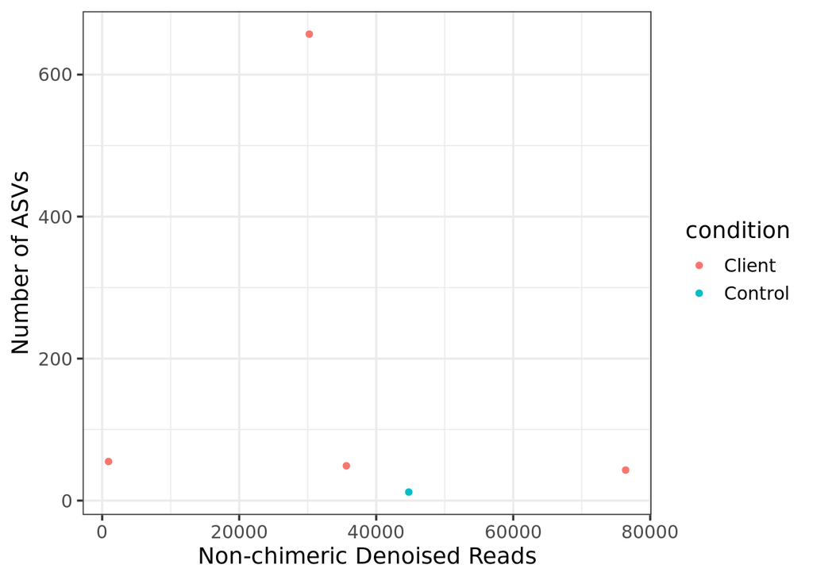

### Top 50 ASVs (VSEARCH classification)

|  | OTU | Kingdom | Phylum | Class | Order | Family | Genus | Species | SH | 5C | 5D | 5B | 5A | 5E_control |
| --- | --- | --- | --- | --- | --- | --- | --- | --- | --- | --- | --- | --- | --- | --- |
| 1 | 7484ba1d0e04bed0523e7da482c307aa | Fungi | Basidiomycota | Agaricomycetes | Boletales | Boletaceae | Rossbeevera | Rossbeevera sp | SH1639932.09FU | 0 | 33227 | 0 | 0 | 0 |
| 2 | ef74d00dd7fdcaf19b6fa2f68394e0bb | Fungi | Basidiomycota | Agaricomycetes | Boletales | Boletaceae | Rossbeevera | Rossbeevera sp | SH1639932.09FU | 0 | 20385 | 78 | 0 | 0 |
| 3 | 477b9ffeafac789e9a5493516394cd1d | Fungi | Basidiomycota | Agaricomycetes | Boletales | Boletaceae | Rossbeevera | Rossbeevera sp | SH1639932.09FU | 0 | 1974 | 12249 | 0 | 0 |
| 4 | ca12e95818370172e1f50d2c141f2f0c | Fungi | Basidiomycota | Agaricomycetes | Agaricales | Physalacriaceae | Flammulina | Flammulina filiformis | SH1666851.09FU | 0 | 0 | 0 | 0 | 13486 |
| 5 | b5188830d3b61ca6f99dbff1597fe728 | Fungi | Basidiomycota | Agaricomycetes | Boletales | Boletaceae | Rossbeevera | Rossbeevera sp | SH1639932.09FU | 0 | 0 | 10384 | 0 | 0 |
| 6 | c0079d9e78e1fbde782ae50d5b2910ba | Unassigned |  |  |  |  |  |  |  | 0 | 8994 | 1323 | 0 | 0 |
| 7 | d4df878f35011932eaf6602561090a6c | Fungi | Basidiomycota | Agaricomycetes | Agaricales | Pleurotaceae | Pleurotus | Pleurotus ostreatus | SH2065513.09FU | 0 | 0 | 0 | 0 | 8420 |
| 8 | d2f34ffd1dfdd80f026dec863500ae6c | Fungi | Basidiomycota | Agaricomycetes | Agaricales | Physalacriaceae | Flammulina | Flammulina filiformis | SH1666851.09FU | 0 | 0 | 0 | 0 | 8115 |
| 9 | bb2514d054c4b4d371f03227bc0a43ff | Fungi | Basidiomycota | Agaricomycetes | Agaricales | Pleurotaceae | Pleurotus | Pleurotus ostreatus | SH2065513.09FU | 0 | 0 | 0 | 0 | 8075 |
| 10 | c43aabe7f1d31730bf2495beaa0c36f8 | Fungi | Basidiomycota | Agaricomycetes | Agaricales | Cortinariaceae | Cortinarius | Cortinarius globuliformis | SH1810800.09FU | 0 | 570 | 5322 | 0 | 0 |

[output cut: 40 more lines]

### Top 10 Classified Genus (Collapsed to species) with VSEARCH

|  | Genus | Mean supporting reads across samples | Mean relative abundance across samples |
| --- | --- | --- | --- |
| 1 | Rossbeevera | 15978 | 0.28 |
| 2 | Cortinarius | 1852.2 | 0.1 |
| 3 | Flammulina | 4320.2 | 0.1 |
| 4 | Pleurotus | 3765.4 | 0.08 |
| 5 | Oidiodendron | 387.2 | 0.03 |
| 6 | Penicillium | 375.8 | 0.03 |
| 7 | Agaricus | 850.4 | 0.02 |
| 8 | Agaricomycetes gen Incertae sedis | 229.2 | 0.01 |
| 9 | Agaricales gen Incertae sedis | 0.8 | 0 |
| 10 | Alveolata gen Incertae sedis | 2.4 | 0 |

[output cut: 95 more lines]

|  | Genus | Species | 5C | 5D | 5B | 5A | 5E_control |
| --- | --- | --- | --- | --- | --- | --- | --- |
| 1 | Rossbeevera | Rossbeevera sp | 0 | 56207 | 23661 | 22 | 0 |
| 2 | Cortinarius | Cortinarius globuliformis | 94 | 1057 | 5978 | 11 | 0 |
| 3 | Cortinarius | Cortinarius sp | 141 | 6 | 388 | 1586 | 0 |
| 4 | Flammulina | Flammulina filiformis | 0 | 0 | 0 | 0 | 21601 |
| 5 | Pleurotus | Pleurotus ostreatus | 0 | 0 | 0 | 0 | 18827 |
| 6 | Oidiodendron |  | 0 | 0 | 0 | 25 | 0 |
| 7 | Oidiodendron | Oidiodendron sp | 85 | 0 | 91 | 1735 | 0 |
| 8 | Penicillium | Penicillium penarojense | 6 | 0 | 0 | 102 | 0 |
| 9 | Penicillium | Penicillium restrictum | 94 | 7 | 13 | 1539 | 0 |
| 10 | Penicillium | Penicillium sp | 3 | 0 | 0 | 115 | 0 |

[output cut: 107 more lines]

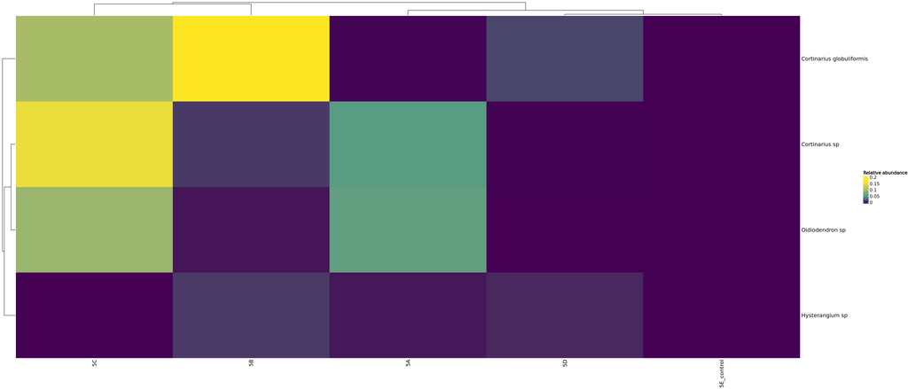